# American Journal of Botany

[American Journal of Botany](https://bsapubs.onlinelibrary.wiley.com/journal/15372197)

[Volume 92, Issue 12](https://bsapubs.onlinelibrary.wiley.com/toc/15372197/2005/92/12) p. 2101-2106

[figure not shown]

Brief Communication

Free Access

# The compensatory responses of an understory herb to experimental damage are habitat-dependent†

[Emilio M. Bruna](https://bsapubs.onlinelibrary.wiley.com/action/doSearch?ContribAuthorRaw=Bruna%2C+Emilio+M),

Author for correspondence ()

[Maria Beatriz Nogueira Ribeiro](https://bsapubs.onlinelibrary.wiley.com/action/doSearch?ContribAuthorRaw=Ribeiro%2C+Maria+Beatriz+Nogueira),

First published: 01 December 2005

https://doi.org/10.3732/ajb.92.12.2101

Citations: 18

Check for Full Text

†

The authors wish to thank O. F. da Silva for assistance in the field and J. Schafer, S. Alvarez-Clare, and two anonymous reviewers for helpful discussions or comments on the manuscript. We also thank the BDFFP for providing logistical support and the Manaus Free Trade Zone Authority (SUFRAMA) for permission to conduct the research. This work was supported by the National Science Foundation (grants DEB-0309819 and INT 98-06351) and the University of Florida. This is publication number 445 in the BDFFP Technical Series.

## Abstract

Canopy gap formation strongly influences the diversity and dynamics of both tropical and temperate forests. It is often viewed as inherently beneficial for understory plants, primarily because growth and flowering are enhanced when light is no longer a limiting resource. It can also be detrimental, however, because plants can be damaged by falling crowns or branches. To elucidate the responses of the Amazonian understory herb *Heliconia acuminata* to damage sustained during gap formation, we transplanted both experimentally damaged and control plants to canopy gaps and the forest understory. We then measured their patterns of growth and biomass allocation 10 mo later. Despite losing approximately 50% of their leaf area, all damaged plants survived the duration of our experiment. Furthermore, damaged plants transplanted to gaps had relative growth rates that far exceeded those of undamaged plants in both gaps and the forest understory. There were also significant interactions between damage and destination habitat type on root to shoot ratios and leaf-area ratios. Our results suggest the ability of herbaceous plants to recover from damage, as well as patterns of post-damage biomass allocation, may be habitat-dependent in ways that have previously remained unexplored.

The process of canopy gap formation has a profound influence on the diversity and dynamics of forests (Dirzo et al., 1992; Hubbell et al., 1999; Beckage et al., 2000). Gap formation is often viewed as inherently beneficial for plants, primarily because growth and flowering are enhanced when light is no longer a limiting resource (Denslow et al., 1990; Saunders and Puettmann, 1999a; Blundell and Peart, 2001; Dalling et al., 2004). In addition, soil disturbance and increased irradiance can stimulate the germination of seeds in the seed bank and establishment of seedlings (Ellison et al., 1993; Pearson et al., 2002; Figueroa, 2003). However, gap formation can also have adverse consequences for plants, such as causing physical damage to them via falling crowns or branches (Clark and Clark, 1989, 1991; Gartner, 1989; Scariot, 2000). Damage to plants can reduce their probability of survival (Clark and Clark, 1991), alter their patterns of biomass allocation (Bergstrom et al., 2000; Blundell and Peart, 2001), or reduce their growth rates (Sipe and Bazzaz, 2001). Disparities between damaged and undamaged plants could potentially alter the outcome of interspecific competition or other ecological interactions and hence have important consequences for patterns of forest regeneration and community composition.

Numerous studies have compared the growth of plants in gaps and the adjacent forest understories (Denslow et al., 1990; Restrepo and Vargas, 1999; Lewis and Tanner, 2000; Lindh et al., 2003). Similarly, studies assessing the responses of plants to natural or experimental damage are also common (Chazdon, 1991; Nunezfarfan and Dirzo, 1991; Dominguez and Dirzo, 1994; Koptur et al., 1996; Guariguata, 1998). However, studies investigating how canopy condition and damage interact to influence plant growth and physiology remain limited. These experiments, which have been conducted primarily in temperate ecosystems (e.g., Saunders and Puettmann, 1999b; Sipe and Bazzaz, 2001) or with the juvenile stages of tropical woody plants (e.g., Howe, 1990; Nunezfarfan and Dirzo, 1991; Osunkjoya et al., 1992; Blundell and Peart, 2001), have generally found that both light availability and damage influence post-damage patterns of survivorship and growth.

Herbaceous species, which account for as much as 25% of the plant diversity in tropical forests (Gentry and Emmons, 1987; Gentry, 1990) and whose dynamics are often gap-dependent (Horvitz and Schemske, 1994; Valverde and Silvertown, 1997; Calvo-Irabien and Islas-Luna, 1999), have remained conspicuously underutilized as model systems with which to investigate the consequences of damage (Cooley et al., 2004). Several factors suggest the responses of understory herbs to damage will be substantially different from those of woody plants. First, much of the biomass of herbs is in rhizomes or other underground storage organs (e.g., Bruna et al., 2002) from which plants may be able to reallocate resources for the regeneration of damaged aboveground tissue. Second, many herbs have multiple stems or grow clonally (Cooley et al., 2004). A single event is therefore unlikely to damage all stems or ramets, enhancing the probability of individual survival. Finally, because herbs lack bark, they may have relatively more resources to invest in leaf and shoot growth following damage than woody plants.

We conducted an experiment to elucidate the responses of tropical understory herbs to damage sustained during gap formation. Using the model system *Heliconia acuminata* (Heliconiaceae), we addressed the following question: how does habitat type (canopy gaps vs. forest understory) influence post-damage patterns of plant growth and biomass allocation?

## MATERIALS AND METHODS

### Study site and species

This study was conducted in Reserve 1501 of Brazil's Biological Dynamics of Forest Fragments Project (BDFFP; 2°30′ S, 60° W), located ca. 70 km north of Manaus. This 800-ha reserve is embedded in a 1000-km<sup>2</sup> landscape dominated by primary nonflooded forest; the canopy reaches a height of 35–45 m, and the understory is dominated by stemless palms. Annual rainfall in the reserve ranges from 1900 to 2300 mm, with a distinct dry season from June to November. Mean annual temperature is 26°C (range 19°–39°). For more details regarding the site see Bierregaard et al. (2002).

*Heliconia acuminata* LC (Richard) is a perennial monocot native to central Amazonia (Kress, 1990). The density of *H. acuminata* in the BDFFP reserves ranges from 250 to 1600 individuals ha<sup>−1</sup> (Bruna and Kress, 2002; E. M. Bruna and W. J. Kress, unpublished data), making it one of the most common plants in the forest understory. Each plant has a basal rhizome from which emerge erect vegetative shoots with broad leaves, as well as one or more flowering shoots if the plant is reproductive. *Heliconia acuminata* does not reproduce vegetatively (E. M. Bruna, personal observation).

A key advantage of using *H. acuminata* to investigate the environmental factors influencing plant growth is the limited impact of foliar herbivores. Throughout the neotropics, the primary herbivores of *Heliconia* are hispine beetles (Chrisomelidae), which cause leaf scarring and readily identifiable perforations but remove little foliar tissue (Strong, 1977; E. M. Bruna, personal observation). Therefore, changes in leaf area observed during our experiment are not attributable to differences in herbivory between habitat types.

### Experimental manipulations and transplants

In August of 2002, we walked along the network of trails bisecting Reserve 1501 and collected 80 *H. acuminata* from the forest understory; no more than three plants were collected from a 100-m section of each trail. These plants had 2–4 vegetative shoots; in a recent demographic survey conducted in our sites the number of shoots per plant was 3.0 ± 0.07 (mean ± SE; *N* = 747 plants; E. M. Bruna, unpublished data). All plants were transplanted to 1.5-L pots filled with homogenized local soil and placed in a common garden in the forest understory. Plants were watered daily to ease transplant shock.

After the plants acclimated to the common garden for 30 d, we randomly assigned each plant to one of two experimental treatments: (a) unmanipulated controls or (b) the removal of half of the vegetative shoots with clippers. This level of damage is similar to that suffered by plants in gaps (E. M. Bruna, unpublished data) and is equivalent to removing approximately 50% of a plant's total leaf area (Fig. 1). Twenty plants from each experimental treatment were then randomly assigned to one of two sites located 400 m apart. Each site was composed of an approximately 100-m<sup>2</sup> treefall gap and a 100-m<sup>2</sup> area of closed canopy forest located 30 m away in a randomly selected direction. We chose this gap size for our experimental transplants because it is the most common size of gap in neotropical forests (Sanford et al., 1986).

For each site, 10 plants from each treatment were randomly assigned to either the understory or the gap; these plants were then arranged in random order along three transects with at least 2 m between plants. Plants were kept in their original pots, and the pots were buried to a depth of 10 cm to minimize the potentially confounding effects of root competition with established plants and of local differences in soil texture and chemistry. While some nutrient passage or root emergence was possible via the drainage holes along the sides and bottom of the pots, we believe it was negligible. We observed no cases of roots emerging through the drainage holes in our pots at the conclusion of our experiment.

### Statistical analysis

We used two-way analysis of variance to compare plant responses to treatments. Habitat type (gap or understory) and damage (50% of stems removed or control) were treated as fixed main effects, with each gap/understory pair as an experimental block. We included initial total leaf area (i.e., before clipping) as a covariate in all analyses. Initial analysis indicated block effects were not significant, therefore we pooled the data from the two sites and present the results of those analyses here. When necessary, we transformed data to meet the assumptions of parametric statistics, but we present back-transformed values throughout the text and in the figures. All analyses were conducted using Systat 10.2 (SSI, 2001).

## RESULTS

While there was no main effect of damage treatment on root to shoot ratio, there was a significant habitat type × treatment interaction (Table 1). In gaps, the final R : S ratio of control plants was higher than that of damaged plants (2.052 ± 0.232 g · g<sup>−1</sup> vs. 1.327 ± 0.090 g · g<sup>−1</sup>, respectively), while the pattern was reversed in the forest understory (R : S<sub>control</sub> = 0.962 ± 0.108 g · g<sup>−1</sup> vs. R : S<sub>damaged</sub> = 1.635 ± 0.283 g · g<sup>−1</sup>, respectively; Fig. 2C). Leaf area ratio was higher in the forest understory than in gaps (78.09 ± 4.43 cm<sup>2</sup> · g<sup>−1</sup> vs. 52.34 ± 2.77 cm<sup>2</sup> · g<sup>−1</sup>), and there was a significant interaction of habitat and treatment (Table 1). While control plants in gaps had the lowest average LAR (44.91 ± 4.43 cm<sup>2</sup> · g<sup>−1</sup>), the highest mean LAR was for control plants in the understory (87.21 ± 4.97 cm<sup>2</sup> · g<sup>−1</sup>; Fig. 2D).

## DISCUSSION

Canopy gap formation is a major source of disturbance in both tropical and temperate forests. However, little is known regarding how plants respond to the damage they sustain during gap creation. Our results indicate that the ability of plants to recover from damage can be habitat-dependent in ways that remained unexplored. Damaged plants transplanted to gaps had relative growth rates that far exceeded those of undamaged ones, while the growth rates of damaged and undamaged plants were similarly low in the forest understory (Figs. 1, 2). Only 1–2% of photosynthetically active radiation (PAR) typically penetrates the forest canopy and reaches the understory (Chazdon and Fetcher, 1984), but PAR levels increase dramatically in gaps. Our results suggest that elevated levels of PAR interact with damage to stimulate rapid compensatory growth, although the mechanisms responsible remain unclear.

Compensatory growth and biomass allocation patterns have also been observed in studies simulating herbivory with mechanical damage (e.g., Howe, 1990; Blundell and Peart, 2001; Parra-Tabla et al., 2004). These studies also indicate plants in high-light environments are more able to compensate for losses of leaf tissue than those in shaded understories. For instance, Blundell and Peart (2001) found that *Shorea quadrinervis* (Dipterocarpaceae) saplings transplanted to gaps after experimentally removing 10% of each leaf grew taller than undamaged control individuals. In fact, only after 90% defoliation did the growth rates of damaged plants fall below those of controls. Similar responses were observed by Kabeya et al. (2003), where the resprouting ability of clipped *Quercus crispula* (Fagaceae) seedlings was enhanced in gaps. The type, extent, and intensity of damage caused by real herbivores can differ substantially from that caused by mechanical damage or debris. Nevertheless, our results and those of previous studies suggest compensatory growth responses to different types of damage are potentially widespread—both geographically and in terms of plant life-history strategy—and that the interactive effects of damage and local light environment can strongly influence patterns of plant growth and biomass allocation.

Other environmental and physiological factors may also influence compensatory growth. First, Hicks and Turkington (2000) found that the magnitude of post-clipping growth was partly related to soil nutrient availability, with plants less able to compensate in high-fertility soils. Future work should therefore consider the potential for intersite variability in soil chemical and physical parameters to influence post-damage responses. Second, the amount of damage a plant receives and how often a plant is damaged, both of which were constant in our experiments, could also influence post-damage responses. In a comprehensive series of greenhouse experiments, for instance, Anten et al. (2003) subjected plants to varying degrees of repeated defoliation. They found that increased defoliation generally led to lower rates of aboveground and laminar growth (see Fig. 2 in Anten et al., 2003). Third, the capacity for compensation may depend in part on the size of a plant when damage is sustained or its initial pattern of biomass allocation. Larger plants may have proportionately more belowground carbohydrates available for allocation to surviving shoots and leaves (McPherson and Williams, 1998), thereby enhancing their compensatory ability following stress (see also Green and Juniper, 2004; Meyers, 2005). As much as 85% of *H. acuminata*'s dry biomass is in the underground rhizome (Bruna et al., 2002; this study), and it is likely that resources are being reallocated from the rhizome to stems and leaves that survive damage (Chazdon, 1992; Landhausser and Lieffers, 2002). Our results were partially consistent with this hypothesis; plant size (e.g., initial total leaf area) was a significant covariate in the ANOVA for final biomass. In future experiments with this system, we will explore the interaction of initial plant size, the intensity and frequency of damage, and habitat type. We will also address the temporal duration of compensation, because long-term patterns of growth and biomass allocation following damage may differ from those observed in our 10-mo experiment.

### Physiological underpinnings of compensatory growth

Although the greatest risk of damage to plants probably comes from large-scale disturbances such as treefalls, plants in the forest understory are also frequently damaged by falling branches, palm fronds, and other types of debris (Gillman et al., 2004; Peters et al., 2004). We found damaged and control *H. acuminata* in the forest understory had similar relative growth rates (Fig. 2A), which is probably why the root to shoot ratio of damaged plants was significantly higher than that of control ones (Fig. 2C). Nevertheless, damaged plants may still have compensated for tissue loss. Because the LAR of damaged plants was lower than that of control plants (Fig. 2D), comparable RGR could only have been maintained via an increase in NAR. A similar conclusion was drawn by Parra-Tabla et al. (2004), who found that experimentally defoliated plants (*Cnidosculus acontifolius*) in low-light environments had similar RGR to control plants despite lower LAR. The elegant method proposed by Anten et al. (2003) is a particularly promising means by which such “hidden” compensatory responses can be detected.

### Implications of compensatory responses

Our results could also have important implications for the conservation of understory plants that are harvested as nontimber forest products (NTFP). The leaves, stems, ramets, or rosettes of *Heliconia*, *Ischnosiphon*, and other herbaceous tropical plants are harvested for the production of handicrafts and other products (reviewed in Ticktin, 2004). Although several comprehensive studies have investigated how postharvesting rates of individual and population recovery are influenced by forest management practices (e.g., Ticktin et al., 2002; Nakazono et al., 2004), few studies have assessed inter-individual differences within a single habitat type resulting from changes in gap dynamics (but see Nakazono et al., 2004; Rodriguez-Buritica et al., 2005). Our results suggest that selectively harvesting from plants in high-light environments where they are capable of compensating for biomass loss could be an important component of sustainable harvesting strategies.

### Conclusion

The results of this and other studies suggest compensatory responses to damage caused by falling debris may be common in herbaceous species, but additional studies of longer duration are needed to elucidate the biotic and abiotic factors influencing the growth of damaged plants. It is also important to note that the identification of compensation depends in large part on the metric used to quantify plant growth (see also Anten et al., 2003). Although we found the final leaf area of damaged plants in gaps was similar to that of undamaged ones, their final biomass was more than 25% lower than that of undamaged plants. Furthermore, whether damaged plants had higher or lower R : S ratios than undamaged controls depended on the habitat type in which they were being compared (Fig. 2C). These results suggest studies attempting to evaluate the compensatory responses of plants should take care to evaluate a suite of indicators of plant performance, in addition to underlying patterns of environmental variation.

Table 1. Results of ANOVA for the effect of experimental treatment (clipping 50% of the stems) and habitat type (gap or understory) on metrics of growth and physiology (A–D) for the Amazonian understory herb *Heliconia acuminate*. The experiment was con ducted at the Biological Dynamics of Forest Fragments Project, which is located near Manaus, Brazil

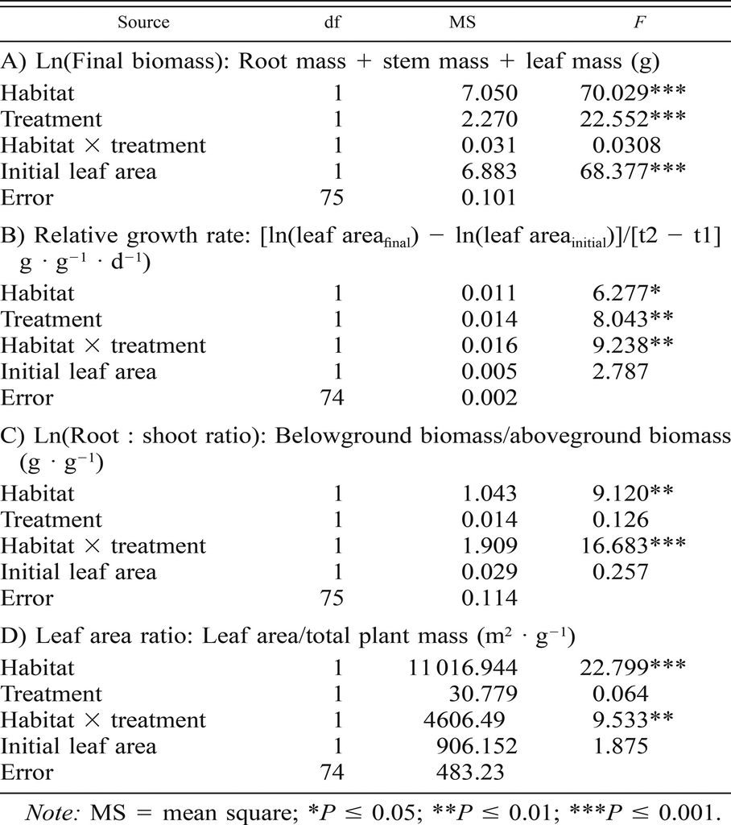

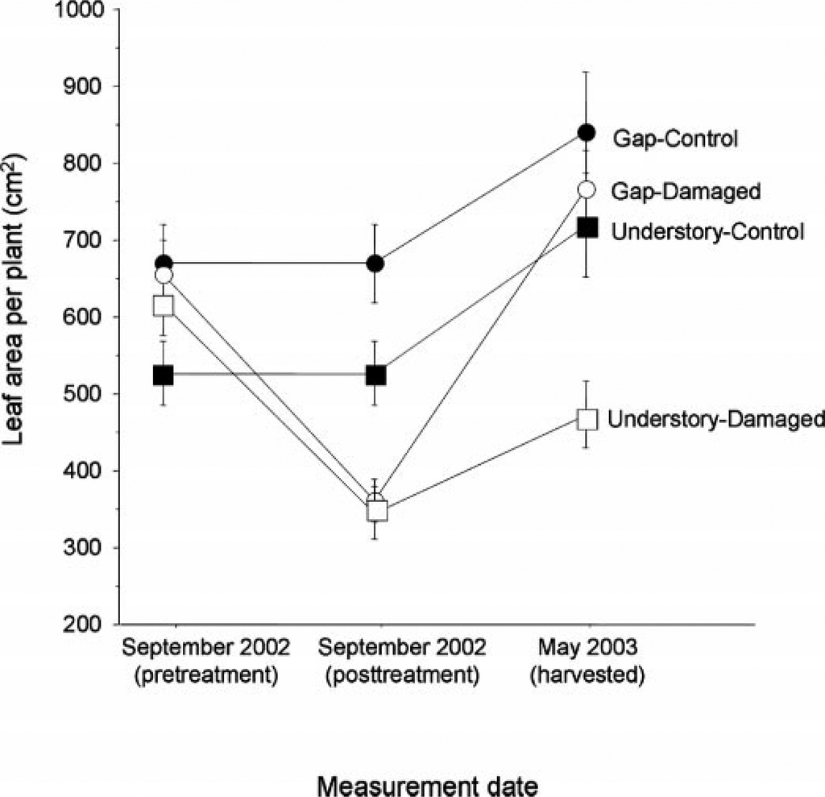

**Figure 1**

Leaf area of plants used in this study before treatment, at the time of leaf removal and transplanting, and at the conclusion of the experiment (means ± SE). Plants were transplanted to gaps (circles) or forest understory sites (squares) in Reserve 1501 of the Biological Dynamics of Forest Fragments Project (Manaus, Brazil). Plants were either experimentally damaged by removing 50% of their stems (open symbols) or were undamaged (filled symbols)

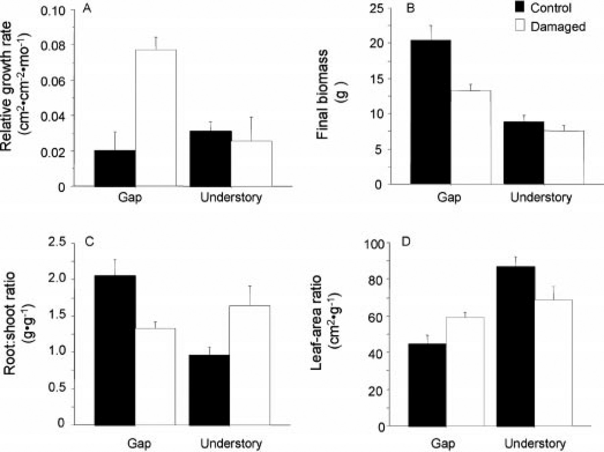

**Figure 2**

Relative growth rate (A), biomass (B), root to shoot ratio (C), and leaf-area ratio (D) (means + 1 SE) 10 mo after transplanting plants to either understory forest or canopy gaps. Plants were either experimentally damaged by clipping 50% of their stems (open bars) or undamaged controls (solid bars)

## Citing Literature

[figure not shown]

[Volume92, Issue12](https://bsapubs.onlinelibrary.wiley.com/toc/15372197/2005/92/12)

December 2005

Pages 2101-2106

beta

- Supporting

  Mentioning16
- Contrasting

  Contrasting1

powered by

[figure not shown]

### Details

© 2005 Botanical Society of America

### Research funding

- National Science Foundation. Grant Numbers: DEB-0309819, INT 98-06351
- University of Florida

### Keywords

- [biomass allocation](https://bsapubs.onlinelibrary.wiley.com/action/doSearch?field1=Keyword&text1=biomass%20allocation)
- compensation
- [*Heliconia acuminata*](https://bsapubs.onlinelibrary.wiley.com/action/doSearch?field1=Keyword&text1=Heliconia%20acuminata)
- Heliconiaceae
- [relative growth rate](https://bsapubs.onlinelibrary.wiley.com/action/doSearch?field1=Keyword&text1=relative%20growth%20rate)
- [treefall gaps](https://bsapubs.onlinelibrary.wiley.com/action/doSearch?field1=Keyword&text1=treefall%20gaps)
- [tropical rain forest](https://bsapubs.onlinelibrary.wiley.com/action/doSearch?field1=Keyword&text1=tropical%20rain%20forest)

### Publication History

- Issue Online: 01 December 2005
- Version of Record online: 01 December 2005
- Manuscript accepted: 12 September 2005
- Manuscript received: 24 May 2005

back